# Chapter 2: Playing out with logistic regression analysis

Again starting off by loading all the packages needed for this analysis

```r
library(dplyr)
```

```r
library(ggplot2)
library(GGally)
library(tidyr)
```

## Data

The dataset at hand is Student Alcohol Consumption Data Set, (see [1] and [data information](https://archive.ics.uci.edu/ml/datasets/STUDENT+ALCOHOL+CONSUMPTION#)). The original survey data is collected on two different classes in two high schools. For this study the data from two different surveys were combined: from mathematics class and from portugese class. Only the students who participated the survey on both classes were included in the analysis, by joining the two datasetss using the background variables. The final dataset includes 382 respondents and 35 variables, listed below in Table 1.

```r
# Table 1
alc <- read.csv("data/alc_final.csv", row.names = 1, header=TRUE)
colnames(alc)
```

```
##  [1] "school"     "sex"        "age"        "address"    "famsize"
##  [6] "Pstatus"    "Medu"       "Fedu"       "Mjob"       "Fjob"
## [11] "reason"     "nursery"    "internet"   "guardian"   "traveltime"
## [16] "studytime"  "failures"   "schoolsup"  "famsup"     "paid"
## [21] "activities" "higher"     "romantic"   "famrel"     "freetime"
## [26] "goout"      "Dalc"       "Walc"       "health"     "absences"
## [31] "G1"         "G2"         "G3"         "alc_use"    "high_use"
```

The purpose of this analysis is to study the predictors of high/low alcohol consumption. High alcohol comsumption is defined as taking more then 2 portions on average per week. We start the exploration with the following set of hypotheses.

First, students with more absenses or more past class failures are most likely to behave badly in other ways too (REF) and hence drink more alcohol.

**H1. Number of school absenses predicts high alcohol consumption.**

**H2. Number of past class failures predicts high alcohol consumption**

Second, alcohol consumption is often related to social activities (REF, REF)

**H3. Higher reported value in going out with friends predicts high alcohol consumption.**

Finally, based on previous national level studies (REF), male students are more likely to consume higher amounts of alcohol compared to women. Hence:

**H4. Male gender predicts high alcohol consumption.**

```r
selected_columns <- c("sex","absences","failures","goout","high_use")
alc_sel <- select(alc, one_of(selected_columns))
```

## Distributions

First lets investigate the distributions of the variables using gather and ggplot. To be honest I’m not sure why the gather-function is needed here.

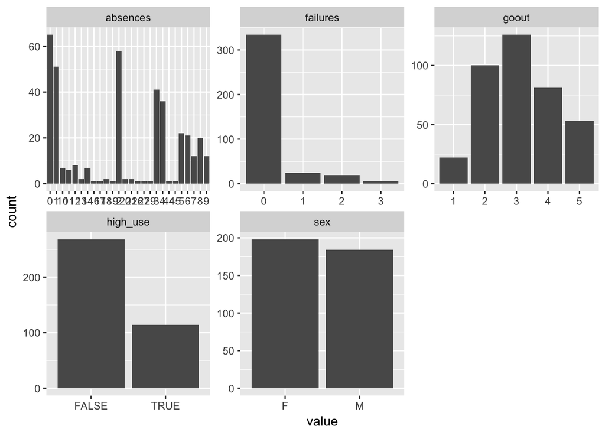

```r
gather(alc_sel) %>% ggplot(aes(value)) + facet_wrap("key", scales = "free") + geom_bar()
```

Next, the selected variables are compared to the variable that classifies the students who take over two doses of alcohol per week as high users of alcohol.

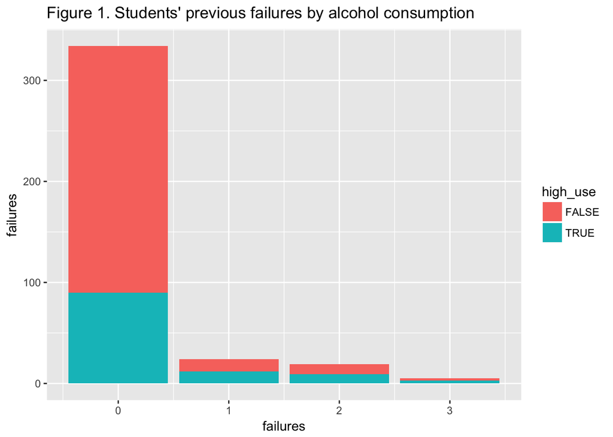

```r
fig1 <- ggplot(alc_sel, aes(x = failures, fill = high_use))
fig1 + geom_bar() + ylab("failures") + ggtitle("Figure 1. Students' previous failures by alcohol consumption")
```

Figure 1 shows students’ previous course failures by alcohol consumption. The distribution is heavily biased towards zero. It is difficult to make any conclusion based on the figure only. Majority of the non-failed student are not high users of alcohol, however.

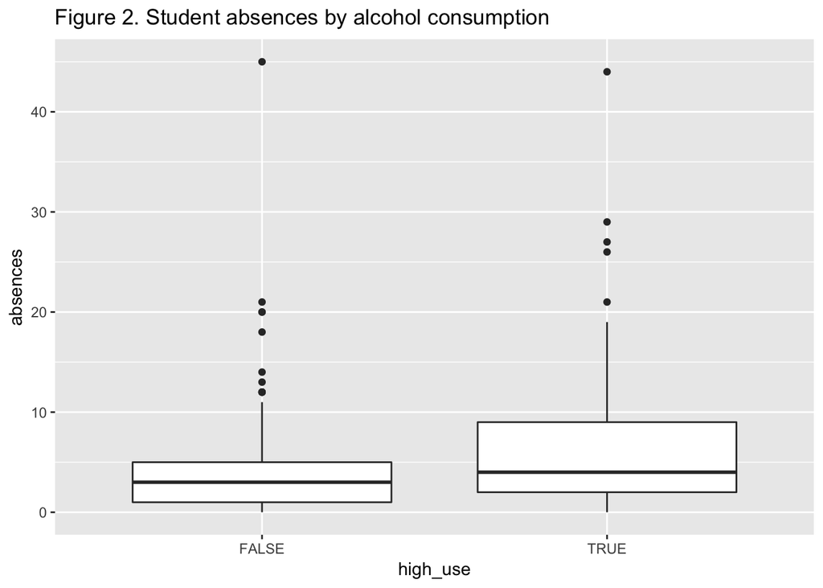

```r
fig2 <- ggplot(alc, aes(x = high_use, y = absences))
fig2 + geom_boxplot() + ylab("absences") + ggtitle("Figure 2. Student absences by alcohol consumption")
```

Figure 2 shows student absences by alcohol consumption. We can observe that high users of alcohol have larger numbers of absences.

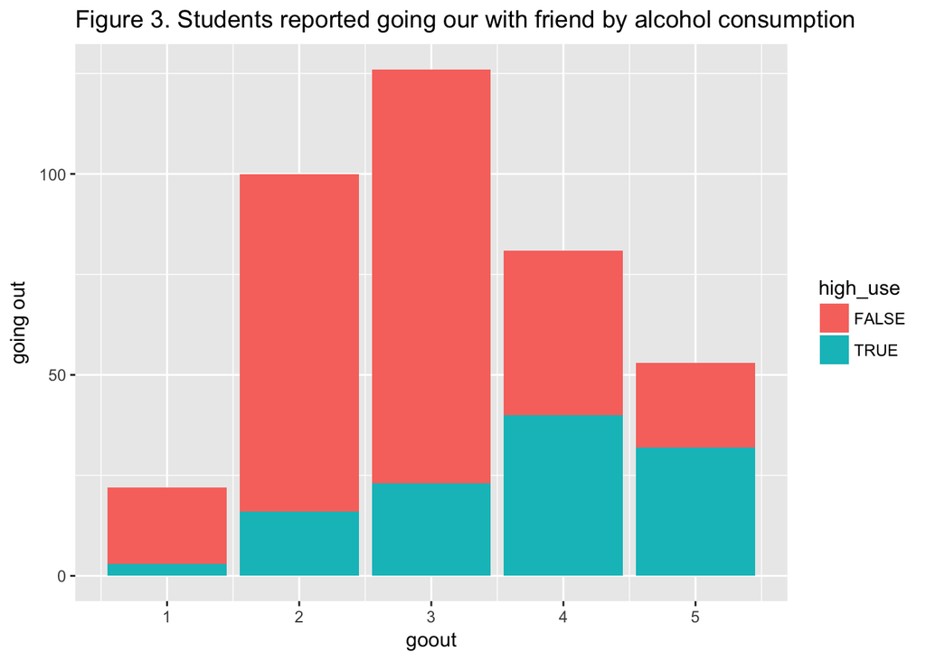

```r
fig3 <- ggplot(alc_sel, aes(x = goout, fill = high_use))
fig3 + geom_bar() + ylab("going out") + ggtitle("Figure 3. Students reported going our with friend by alcohol consumption")
```

Figure 3 shows students’ reported going our with friend by alcohol consumption. It looks like students who are high-users of alcohol are also going out more with their friends. The majority of respondents report going moderately out.

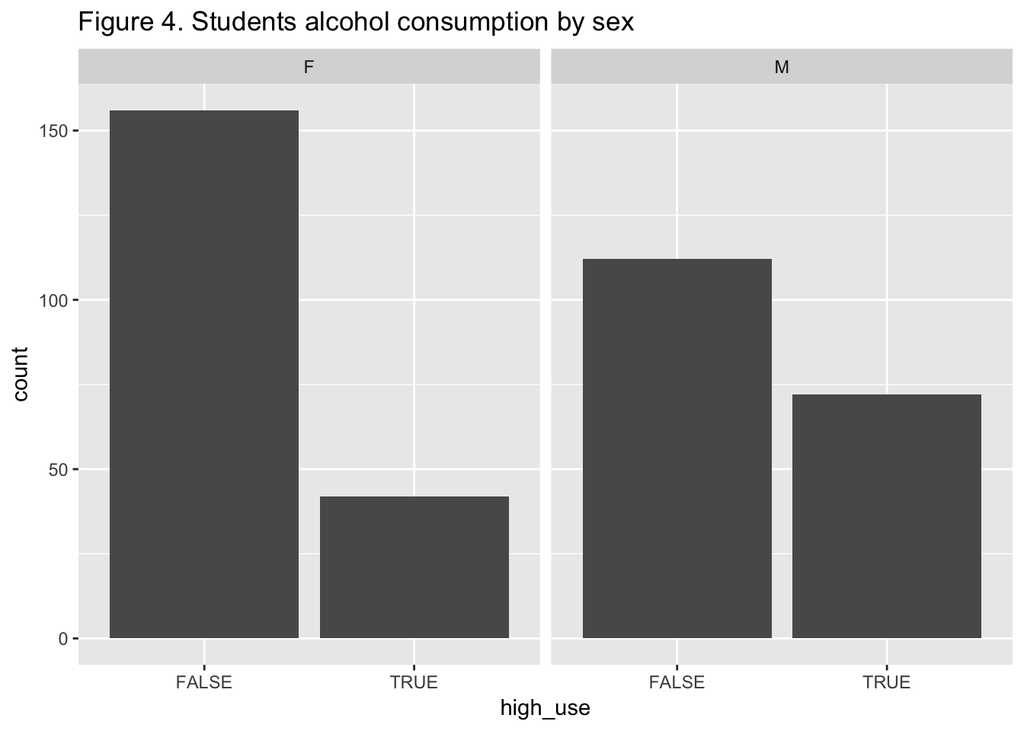

```r
fig4 <- ggplot(data = alc, aes(x = high_use))
fig4 + geom_bar() + facet_wrap("sex") + ggtitle("Figure 4. Students alcohol consumption by sex")
```

Figure 4 shows the distributions or high and low alcohol users by gender. We can observe that in males there are more high users in numbers and also proportionally.

Based on these graps it is reasonable to proceed with these variables. The only exception is previous failures, which is difficult to interpret from the plot.

## Method

In order to test the hypotheses logistic regression was used.

```r
# fit the model
m1 <- glm(high_use ~ goout + failures + absences + sex, data = alc, family = "binomial")
summary(m1)
```

```
##
## Call:
## glm(formula = high_use ~ goout + failures + absences + sex, family = "binomial",
##     data = alc)
##
## Deviance Residuals:
##     Min       1Q   Median       3Q      Max
## -2.0299  -0.7890  -0.5417   0.7857   2.3588
##
## Coefficients:
##             Estimate Std. Error z value Pr(>|z|)
## (Intercept) -4.13390    0.47292  -8.741  < 2e-16 ***
## goout        0.70797    0.11998   5.901 3.62e-09 ***
## failures     0.34560    0.21093   1.638 0.101330
## absences     0.08243    0.02235   3.688 0.000226 ***
## sexM         0.91999    0.25625   3.590 0.000330 ***
## ---
## Signif. codes:  0 '***' 0.001 '**' 0.01 '*' 0.05 '.' 0.1 ' ' 1
##
## (Dispersion parameter for binomial family taken to be 1)
##
##     Null deviance: 465.68  on 381  degrees of freedom
## Residual deviance: 385.06  on 377  degrees of freedom
## AIC: 395.06
##
## Number of Fisher Scoring iterations: 4
```

```r
# compute odds ratios confidence intervals
oddra <- coef(m1) %>% exp
coin <- confint(m1) %>% exp
cbind(oddra, coin)
```

```
##                  oddra       2.5 %     97.5 %
## (Intercept) 0.01602022 0.006086805 0.03902357
## goout       2.02986872 1.613471240 2.58531654
## failures    1.41283378 0.934759890 2.14797583
## absences    1.08592493 1.040580166 1.13727912
## sexM        2.50925591 1.526894419 4.17886012
```

The regression model confirms that three of the four variables are significant in predicting high alcohol use: absences, going out with friends, and male sex. Hence, hypotheses H1, H3 and H4 can be accepted. H2, however, suggested that previous course failures would predict high alcohol use. H2 must be rejected.

Odd rations for all explanatory variables are positive. Students who go out with friends are two times more likely to drink high dosages of alcohol, and male student 2,5 times more likely to drink high dosages. The effect of absences is only slightly above one at 1,09, but the confidence intervals nevertheless remain above one. Hence the positive effect is small but it exists.

For the final model the non-significant predictor of failures is removed.

```r
# fit the new model
m2 <- glm(high_use ~ goout + absences + sex, data = alc, family = "binomial")
summary(m2)
```

```
##
## Call:
## glm(formula = high_use ~ goout + absences + sex, family = "binomial",
##     data = alc)
##
## Deviance Residuals:
##     Min       1Q   Median       3Q      Max
## -1.7871  -0.8153  -0.5446   0.8357   2.4740
##
## Coefficients:
##             Estimate Std. Error z value Pr(>|z|)
## (Intercept) -4.16317    0.47506  -8.764  < 2e-16 ***
## goout        0.72981    0.11970   6.097 1.08e-09 ***
## absences     0.08418    0.02237   3.764 0.000167 ***
## sexM         0.95872    0.25459   3.766 0.000166 ***
## ---
## Signif. codes:  0 '***' 0.001 '**' 0.01 '*' 0.05 '.' 0.1 ' ' 1
##
## (Dispersion parameter for binomial family taken to be 1)
##
##     Null deviance: 465.68  on 381  degrees of freedom
## Residual deviance: 387.75  on 378  degrees of freedom
## AIC: 395.75
##
## Number of Fisher Scoring iterations: 4
```

```r
# compute odds ratios confidence intervals
oddra <- coef(m2) %>% exp
coin <- confint(m2) %>% exp
cbind(oddra, coin)
```

```
##                  oddra       2.5 %     97.5 %
## (Intercept) 0.01555815 0.005885392 0.03804621
## goout       2.07468346 1.650182481 2.64111050
## absences    1.08782902 1.042458467 1.13933894
## sexM        2.60835292 1.593132148 4.33151387
```

Next let’s use the model to predict future values.

```r
# predict() the probability of high_use
probabilities <- predict(m2, type = "response")
alc_sel <- mutate(alc_sel, probability = probabilities)
alc_sel <- mutate(alc_sel, prediction = probability > 0.5)
table(high_use = alc_sel$high_use, prediction = alc_sel$prediction)
```

```
##         prediction
## high_use FALSE TRUE
##    FALSE   253   15
##    TRUE     65   49
```

Hence with this model in the current data set we result with 65 and 15 incorrectly classified students - stupid datapoints who are not following the model!

```r
# a plot of high_use versus probability, prediction as colors
# g <- ggplot(alc_sel, aes(x = probability, y = high_use, col = prediction))
# g + geom_point()
# OMITTING THE PLOT BECAUSE I DON'T FIND IT VERY USEFUL OR ILLUMINATING

# tabulate the target variable versus the predictions
table(high_use = alc_sel$high_use, prediction = alc_sel$prediction) %>% prop.table() %>% addmargins()
```

```
##         prediction
## high_use      FALSE       TRUE        Sum
##    FALSE 0.66230366 0.03926702 0.70157068
##    TRUE  0.17015707 0.12827225 0.29842932
##    Sum   0.83246073 0.16753927 1.00000000
```

```r
# ripping the loss function from datacamp
loss_func <- function(class, prob) {
  n_wrong <- abs(class - prob) > 0.5 # sijoitta 1 n_wrongiin jos oik pätee eli kun arvaus meni pieleen
  mean(n_wrong)
}

# call loss_func to compute the average probablity proportion of wrong predictions in the (training) data
loss_func(class = alc_sel$high_use, prob = alc_sel$probability)
```

```
## [1] 0.2094241
```

This computed average proportion of incorrect predictions means that approximately 20 % of the predictions were incorrect following model m2. This training error is lower than the error achieved e.g. by guessing all students to be low-use alcohol consumers (29%). Hence the performance of the model is not perfect but better than a random guess. More variable testing would be needed to make the model more accurate.

## Conclusion

In the above conducted logistic regression analysis the aim was to study the predictors of high alcohol consumption. Four hypotheses were formulated based on previous research (REF REF). The results show that high number of school absenses, higher reported value in going out with friends, and male sex predict high alcohol consumption.

### References:

[1]. P. Cortez and A. Silva. Using Data Mining to Predict Secondary School Student Performance. In A. Brito and J. Teixeira Eds., Proceedings of 5th FUture BUsiness TEChnology Conference (FUBUTEC 2008) pp. 5-12, Porto, Portugal, April, 2008, EUROSIS, ISBN 978-9077381-39-7.